# 朴素贝叶斯：基于商品名称的自动化分类

韩司仪 20210980106@fudan.edu.cn 李哲 zheli20@fudan.edu.cn

2022年4月18日

# 1 准备工作

```r
# 清除工作环境
cat("\014");rm(list = ls())
```

```r
# 设置工作目录
setwd("../Naive_bayes_kNN/")

# 注释快捷键，ctrl/command+shift+c
# library(gdtools)
# ?sys_fonts # 列出系统字体。
# View(sys_fonts())
# Win10: SimHei、STXihei
```

# 2 数据介绍

商品分类，顾名思义就是根据商品的性质、特点将其划分到合适的类别中。在现代商业社会，商品分类是商品流通的基础步骤之一。目前的商品分类普遍存在三大困难：数据大、信息少、人工繁。本案例针对上述商品分类面对的困难，提出了一套基于商品名称的商品自动化分类体系，它可以完全利用商品名称信息，以自动化的分类技术大批量高效率的对海量商品进行分类处理，从而延伸商品价值。

# 3 读取数据

```r
# tips: option/alt+减号可以打出 <-
#       ctrl/command + enter可以运行光标所在行的代码/选定的代码段
#       R中 true和false可以用TRUE/FALSE or T/F两种方式表示
#       ctrl+shift+m可以打出管道函数 %>%

# 读入catalog数据
# catalog <- read.csv('catalogs.csv', fileEncoding = "utf-8")
# library(data.table)
# catalog <- fread('catalogs.csv')
library(readxl)
catalog <- read_excel("catalogs.xlsx")
# 查看数据
head(catalog)
```

```
## # A tibble: 6 x 4
##   name                                                       first second  third
##   <chr>                                                      <chr> <chr>   <chr>
## 1 双汇 猪舌 700g/袋                                          生鲜  猪牛羊… 猪肉
## 2 （满38减10）黑猪腊肉 湘西腊肉 即食小吃食猪肉干肉脯湖南张…  生鲜  猪牛羊… 猪肉
## 3 精气神 猪肋排段（排骨） 400g/袋 山黑猪  黑猪肉 林间散养    生鲜  猪牛羊… 猪肉
## 4 双汇 猪五花肉片 300g/袋 整肉原切 火锅食材                  生鲜  猪牛羊… 猪肉
## 5 农家散养新鲜现杀黑土猪肉 纯瘦肉  500g                      生鲜  猪牛羊… 猪肉
## 6 精气神 猪腿肉 400g/袋 山黑猪 黑猪肉 林间散养（2件起售）    生鲜  猪牛羊… 猪肉
```

# 4 描述分析

## 4.1 二级分布

数据中包含两个一级品类，即“生鲜”和“食品饮料、保健食品”。我们使用饼状图对每个一级品类生鲜下的各个二级品类的分布情况进行描述分析。

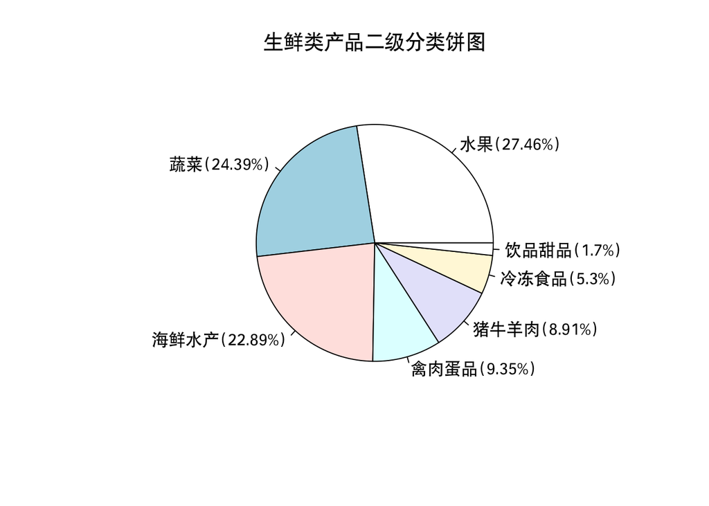

```r
library(plyr)
# 聚合数据
df1 <- ddply(catalog[catalog$first=="生鲜",], .(second), nrow)
# df_temp <- ddply(catalog, .(first, second), nrow)
# View(df_temp)
# help(ddply)
df1 <- df1[order(df1$V1, decreasing = TRUE),]
# 获取标签
label <- as.vector(df1$second)
label <- paste(label, "(", round(df1$V1/sum(df1$V1)*100, 2), "%)", sep = "")
# 使用R自带的饼图函数
pie(df1$V1, labels = label, main = "生鲜类产品二级分类饼图", family = "Hei") # Win10: SimHei、STXihei
```

```r
library(jiebaR)
# 初始化分词工具
seg <- worker(bylines = T, user = 'userdict.dat')
# user_dict\stop_words

# 读入自定义词典
new_words <- read.table('userdict.dat', header = F, stringsAsFactors = F)
# 将词典加入分词引擎
new_user_word(seg, new_words$V1)
```

```
## [1] TRUE
```

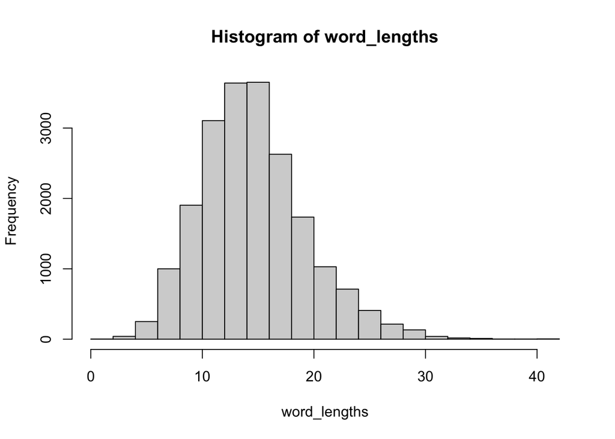

```r
# 分词
catalog$name <- as.character(catalog$name)
cata_seg <- segment(catalog$name, seg)


# 提取出“生鲜”
food_and_drink_seg <- cata_seg[which(catalog$first == "生鲜")]
# 计算不同商品名称包含的词数
word_lengths <- sapply(food_and_drink_seg, length)

hist(word_lengths)
```

## 4.2 正则表达式

- \\:转义符
- ^:匹配输入字符串的开始位置
- $:匹配输入字符串的结束位置
- *:匹配前面的子表达式零次或多次
- +:匹配前面的子表示式一次或多次
- ?:匹配前面的子表达式零次或一次
- .:匹配除$\n$以外的任何单个字符
- x|y:匹配x或y
- [xyz]:字符集和，匹配集合中所包含的任意字符
- [^xyz]:负字符集合，匹配非集合中的任意字符
- [a-z]:字符范围，匹配任意小写字母
- [^a-z]:负值字符范围
- [A-Z]:字符范围，匹配任意大写字母
- [0-9]:字符范围，匹配任意数字
- $[\u4e00-\u9fa5]$:字符范围
- \\s:匹配任意空白字符，包括空格、制表符、换页符等等

```r
# 匹配包含某些关键词的字符串
s0 <- "have a nice day, 666"
#
# "nice" %in% "have a nice day, 666"
# "nice" %in% c("nice", "bad", "good")

grepl("nice", s0)
```

```
## [1] TRUE
```

```r
s <- "<br> <class> <li> 今天天气真好"
ss <- "20210980106@fudan.edu.cn"
grepl("fudan", ss)
```

```
## [1] TRUE
```

```r
"abc\123"
```

```
## [1] "abcS"
```

```r
"abc\\123"
```

```
## [1] "abc\\123"
```

```r
grepl("^[0-9]+@fudan\\.edu\\.cn", ss)
```

```
## [1] TRUE
```

```r
grepl(".+nice.+", s0)
```

```
## [1] TRUE
```

```r
grepl(".+666.*", s0)
```

```
## [1] TRUE
```

```r
# 匹配全是英文字母组成的字符串
s1 <- "asfGYJKhkgdnabuqwKHg"
grepl("^([a-z]|[A-Z])+$", s1)
```

```
## [1] TRUE
```

```r
grepl("^([a-zA-Z])+$", s1)
```

```
## [1] TRUE
```

```r
# 匹配全是数字组成的字符串
s2 <- "34241341"
grepl("^[0-9]+$", s2)
```

```
## [1] TRUE
```

```r
# 匹配中文
s3 <- "数据abc666挖掘"
grepl('^[\u4e00-\u9fa5]+[a-z|A-Z]+[0-9]+[\u4e00-\u9fa5]+$', s3)
```

```
## [1] TRUE
```

## 4.3 商品名称的处理与分析

```r
##前期处理:选择分词引擎，读入自定义词典
library(jiebaR)
library(stringr)
##初始化分词工具
seg = worker(bylines = T)
##读入自定义词典，并加入到分词引擎中，注意到自定义词典中的名称也需要分词
new_words <- read.table('userdict.dat', header = F, stringsAsFactors = F)
new_user_word(seg, new_words$V1)
```

```
## [1] TRUE
```

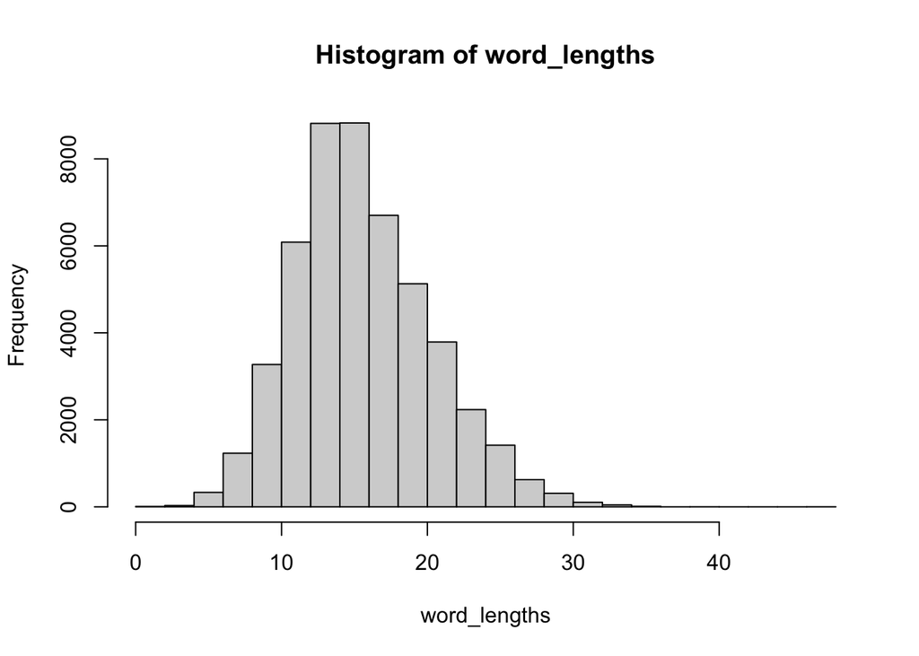

```r
##3.1 数据文本化并进行分词
catalog$name = as.character(catalog$name)
cata_seg = segment(catalog$name, seg)
##3.2 选择食品饮料类数据的分词结果
food_and_drink_seg = cata_seg[which(catalog$first == "食品饮料、保健食品")]
##3.3 计算不同商品名称包含的词数
word_lengths = sapply(food_and_drink_seg, length)
hist(word_lengths)
```

## 4.4 词云图

用词云图观察每个类别的语言特点。这里，我们以【食品饮料】类为例进行展示，绘制该类别下商品名称top100高频词的词云图。同理，大家也可以尝试食品饮料类下面的二级品类“饮料冲调”以及三级品类“牛奶乳品”的词云图，然后进一步去比较不同品类的语言特点。

```r
#利用词云图展现不同级别分类体系下商品名称分词结果(以牛奶乳品为例)
library(wordcloud2)
##4.1 建立分词后词频数据框
food_and_drink_seg_df = data.frame(table(unlist(food_and_drink_seg)))
##4.2 对词频进行降序排列，找到高频词
food_and_drink_seg_df = food_and_drink_seg_df[order(food_and_drink_seg_df$Freq,decreasing = T),]
head(food_and_drink_seg_df)
```

```
##       Var1  Freq
## 27760    g 32837
## 818    500  7521
## 12457 礼盒  7397
## 3077  茶叶  7273
## 26869   装  7039
## 4501    袋  6740
```

```r
##4.3 对前100个词构建词云图
wordcloud2(food_and_drink_seg_df[1:100,])
```

[interactive chart not shown]

# 5 朴素贝叶斯模型

## 5.1 预处理

- 将分词后的数据集按照7:3比例随机拆分为训练集和测试集
- 对分词结果进行预处理：去掉数字字母组合，然后去掉低频词（包含该词的商品数量<10）、高频词（在多于75%的商品名称中出现），在去除低频词和高频词时，你可以使用函数pruned_vocab()
- 保留高频词中的top1000的词语，作为分类器的特征，并建立文档-词频矩阵。在建立文档词频矩阵时，你需要用到text2vec包中的create_dtm()函数
- 最后，给出训练集和测试集的文档词频矩阵的维度

```r
library(text2vec)
##5.1数据集拆分
set.seed(1000)
id <- sample(1:nrow(catalog), 0.7 * nrow(catalog), F)
train <- catalog[id, ]
test <- catalog[-id, ]
train$id <- as.character(1:nrow(train))
test$id <- as.character(1:nrow(test))
##5.2分词结果相应进行拆分
seg_train <- cata_seg[id]
seg_test <- cata_seg[-id]
##5.3去除停用词，筛选特征词，生成语料文件
# 找到分词结果中的纯数字或字母，存入stop_words
stop_words <- unique(unlist(seg_train))
stop_words <- stop_words[grepl('^([a-z]|[A-Z])+$', stop_words)|grepl('^[0-9]+(\\.)?[0-9]*(-)?[0-9]*(\\.)?[0-9]*$', stop_words)]
# stop_words中可能存在一些包含在自定义词典中的专有名词，去掉
stop_words <- setdiff(stop_words, new_words)
# 设置分词迭代器
it_train <- itoken(seg_train, ids = train$id)
it_test <- itoken(seg_test, ids = test$id)
vocab <- create_vocabulary(it_train)
# 修剪低频词、高频词
pruned_vocab <- prune_vocabulary(vocab, doc_count_min = 10, doc_proportion_max = 0.75)
pruned_vocab <- pruned_vocab[!(pruned_vocab$term %in% stop_words), ]
# 保留词频前1000的词语
pruned_vocab <- pruned_vocab[order(pruned_vocab$term_count, decreasing = T), ]
pruned_vocab <- pruned_vocab[1:1000, ]
# 初步形成语料文件
vectorizer <- vocab_vectorizer(pruned_vocab)
##5.4根据语料文件生成文档-词频矩阵
# 文档-词频矩阵
dtm_train <- create_dtm(it_train, vectorizer)
dtm_test <- create_dtm(it_test, vectorizer)
dtm_train <- as.matrix(dtm_train)
dtm_test <- as.matrix(dtm_test)
# 转化为0-1矩阵
dtm_train[dtm_train > 1] <- 1
dtm_test[dtm_test > 1] <- 1
dtm_train <- apply(dtm_train, 2, as.factor)
dtm_test <- apply(dtm_test, 2, as.factor)
dim(dtm_train)
```

```
## [1] 48645  1000
```

```r
dim(dtm_test)
```

```
## [1] 20849  1000
```

## 5.2 建立模型

以文档词频矩阵为自变量，以每个商品名称对应的二级分类为因变量，建立自动化分类模型。以生鲜类为例，对训练集建立朴素贝叶斯分类器，你需要用到e1071包里面的naiveBayes()函数。

```r
library(e1071)
train_fresh <- train[train$first == '生鲜', ]
test_fresh <- test[test$first == '生鲜', ]
dtm_train_fresh <- dtm_train[train$first == '生鲜', ]
dtm_test_fresh <- dtm_test[test$first == '生鲜', ]
##6.1 根据训练集数据，建立朴素贝叶斯分类器
nb <- naiveBayes(x = dtm_train_fresh, y = as.factor(train_fresh$second), laplace = 0)
##6.2 在测试集上做预测
pred <- predict(nb, dtm_test_fresh, type = 'class')
##6.3 计算准确率
accuracy <- sum(as.character(test_fresh$second) == as.character(pred)) / nrow(test_fresh)
print(paste0('二级品类：', accuracy))
```

```
## [1] "二级品类：0.901765282772148"
```

## 5.3 混淆矩阵

```r
##7.1输出混淆矩阵，以朴素贝叶斯在二级品类上预测结果为例
real02 <- as.character(test_fresh$second[test_fresh$first == '生鲜'])
tab <- table(pred, as.character(test_fresh$second))
tab <- tab[c(unique(real02)), c(unique(real02))]
tab[tab == 0] <- NA
print(list(ConfusionMatrix = tab))
```

```
## $ConfusionMatrix
##
## pred       猪牛羊肉 饮品甜品 水果 蔬菜 禽肉蛋品 冷冻食品 海鲜水产
##   猪牛羊肉      488        1    1    3       13        5       17
##   饮品甜品               103    3    2                          4
##   水果                       1535   38        5        3        6
##   蔬菜           19            83 1332       28       15       33
##   禽肉蛋品       35             1   19      502       10       13
##   冷冻食品       19        1    3   56       12      238       28
##   海鲜水产       16        1   35   35       14       24     1319
```